# I will start with a pretrained word embedding on this IMDB reviews use case

# The LSTM validation accuracy has a decent increase from 78.24% to 80.37%.

Lets increase the training samples to 3000 if the performance gets better or worse

```
Found 88582 unique tokens.
Shape of data tensor: (25000, 150)
Shape of label tensor: (25000,)
```

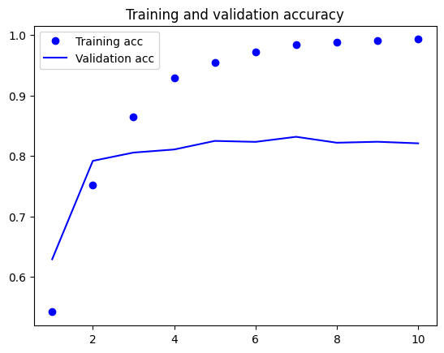

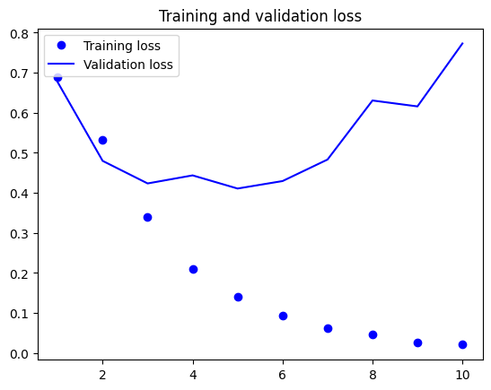

```
Training Accuracy = 0.9929999709129333
Validation Accuracy = 0.8209999799728394
```

```python
maxlen = 150 # Cut off reviews after 150 words
training_samples = 3000 # Number of training samples
validation_samples = 10000 # Number of validation samples
max_words = 10000 # Consider only the top 10000 words

x_train, y_train, x_val, y_val, word_index = preprocess_text_data(texts, labels, max_words, maxlen, training_samples, validation_samples)

model = Sequential()
model.add(Embedding(max_words, 32))
model.add(LSTM(32))
model.add(Dense(1, activation='sigmoid'))
model.compile(optimizer='rmsprop', loss='binary_crossentropy', metrics=['acc'])
history = model.fit(x_train, y_train, epochs=10, batch_size=32, validation_data=(x_val, y_val))

model.save_weights('simple_LSTM_model_3000.h5')


acc = history.history['acc']
val_acc = history.history['val_acc']
loss = history.history['loss']
val_loss = history.history['val_loss']
epochs = range(1, len(acc) + 1)
plt.plot(epochs, acc, 'bo', label='Training acc')
plt.plot(epochs, val_acc, 'b', label='Validation acc')
plt.title('Training and validation accuracy')
plt.legend()
plt.figure()
plt.plot(epochs, loss, 'bo', label='Training loss')
plt.plot(epochs, val_loss, 'b', label='Validation loss')
plt.title('Training and validation loss')
plt.legend()
plt.show()

# Access the training and validation accuracy from the history by taking the last epoch's accuracy
training_accuracy = history.history['acc']
print(f"Training Accuracy = {training_accuracy[-1]}")

validation_accuracy = history.history['val_acc']
print(f"Validation Accuracy = {validation_accuracy[-1]}")
```

# It is a increase from the previous model(80.37% to 82.1%)

Lets increase the samples to 5000

```
Found 88582 unique tokens.
Shape of data tensor: (25000, 150)
Shape of label tensor: (25000,)
```

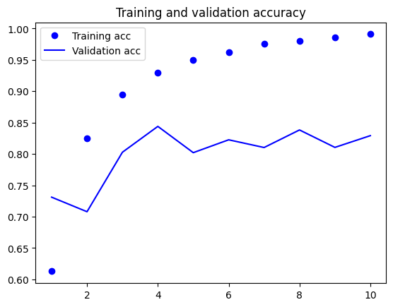

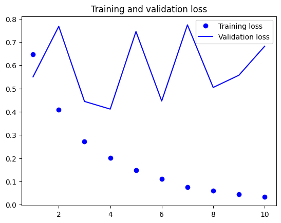

```
Training Accuracy = 0.9909999966621399
Validation Accuracy = 0.829200029373169
```

```python
maxlen = 150 # Cut off reviews after 150 words
training_samples = 5000 # Number of training samples
validation_samples = 10000 # Number of validation samples
max_words = 10000 # Consider only the top 10000 words

x_train, y_train, x_val, y_val, word_index = preprocess_text_data(texts, labels, max_words, maxlen, training_samples, validation_samples)

model = Sequential()
model.add(Embedding(max_words, 32))
model.add(LSTM(32))
model.add(Dense(1, activation='sigmoid'))
model.compile(optimizer='rmsprop', loss='binary_crossentropy', metrics=['acc'])
history = model.fit(x_train, y_train, epochs=10, batch_size=32, validation_data=(x_val, y_val))

model.save_weights('simple_LSTM_model_5000.h5')


acc = history.history['acc']
val_acc = history.history['val_acc']
loss = history.history['loss']
val_loss = history.history['val_loss']
epochs = range(1, len(acc) + 1)
plt.plot(epochs, acc, 'bo', label='Training acc')
plt.plot(epochs, val_acc, 'b', label='Validation acc')
plt.title('Training and validation accuracy')
plt.legend()
plt.figure()
plt.plot(epochs, loss, 'bo', label='Training loss')
plt.plot(epochs, val_loss, 'b', label='Validation loss')
plt.title('Training and validation loss')
plt.legend()
plt.show()

# Access the training and validation accuracy from the history by taking the last epoch's accuracy
training_accuracy = history.history['acc']
print(f"Training Accuracy = {training_accuracy[-1]}")

validation_accuracy = history.history['val_acc']
print(f"Validation Accuracy = {validation_accuracy[-1]}")
```

# It is a decent increase from 82.1% to 82.92% .

Lets increase training examples to 7500

```
Found 88582 unique tokens.
Shape of data tensor: (25000, 150)
Shape of label tensor: (25000,)
```

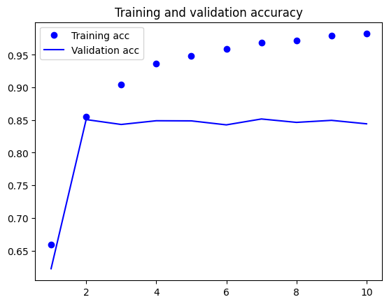

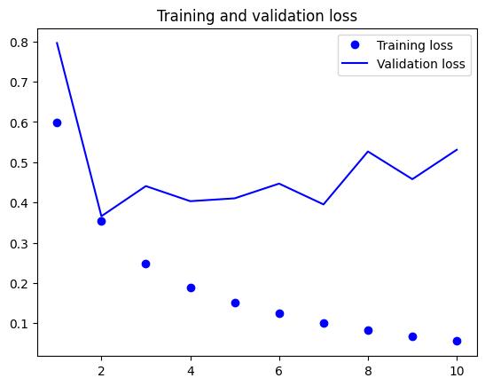

```
Training Accuracy = 0.9819999933242798
Validation Accuracy = 0.8442000150680542
```

```python
maxlen = 150 # Cut off reviews after 150 words
training_samples = 7500 # Number of training samples
validation_samples = 10000 # Number of validation samples
max_words = 10000 # Consider only the top 10000 words

x_train, y_train, x_val, y_val, word_index = preprocess_text_data(texts, labels, max_words, maxlen, training_samples, validation_samples)

model = Sequential()
model.add(Embedding(max_words, 32))
model.add(LSTM(32))
model.add(Dense(1, activation='sigmoid'))
model.compile(optimizer='rmsprop', loss='binary_crossentropy', metrics=['acc'])
history = model.fit(x_train, y_train, epochs=10, batch_size=32, validation_data=(x_val, y_val))

model.save_weights('simple_LSTM_model_7500.h5')


acc = history.history['acc']
val_acc = history.history['val_acc']
loss = history.history['loss']
val_loss = history.history['val_loss']
epochs = range(1, len(acc) + 1)
plt.plot(epochs, acc, 'bo', label='Training acc')
plt.plot(epochs, val_acc, 'b', label='Validation acc')
plt.title('Training and validation accuracy')
plt.legend()
plt.figure()
plt.plot(epochs, loss, 'bo', label='Training loss')
plt.plot(epochs, val_loss, 'b', label='Validation loss')
plt.title('Training and validation loss')
plt.legend()
plt.show()

# Access the training and validation accuracy from the history by taking the last epoch's accuracy
training_accuracy = history.history['acc']
print(f"Training Accuracy = {training_accuracy[-1]}")

validation_accuracy = history.history['val_acc']
print(f"Validation Accuracy = {validation_accuracy[-1]}")
```

# It is a slight increase from 82.92% to 84.42%.

Lets increase training examples to 10000

```
Found 88582 unique tokens.
Shape of data tensor: (25000, 150)
Shape of label tensor: (25000,)
```

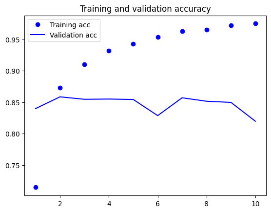

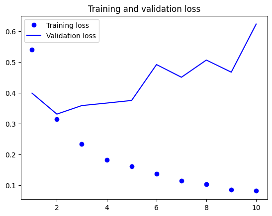

```
Training Accuracy = 0.9746999740600586
Validation Accuracy = 0.8198000192642212
```

```python
maxlen = 150 # Cut off reviews after 150 words
training_samples = 10000 # Number of training samples
validation_samples = 10000 # Number of validation samples
max_words = 10000 # Consider only the top 10000 words

x_train, y_train, x_val, y_val, word_index = preprocess_text_data(texts, labels, max_words, maxlen, training_samples, validation_samples)

model = Sequential()
model.add(Embedding(max_words, 32))
model.add(LSTM(32))
model.add(Dense(1, activation='sigmoid'))
model.compile(optimizer='rmsprop', loss='binary_crossentropy', metrics=['acc'])
history = model.fit(x_train, y_train, epochs=10, batch_size=32, validation_data=(x_val, y_val))

model.save_weights('simple_LSTM_model_10000.h5')


acc = history.history['acc']
val_acc = history.history['val_acc']
loss = history.history['loss']
val_loss = history.history['val_loss']
epochs = range(1, len(acc) + 1)
plt.plot(epochs, acc, 'bo', label='Training acc')
plt.plot(epochs, val_acc, 'b', label='Validation acc')
plt.title('Training and validation accuracy')
plt.legend()
plt.figure()
plt.plot(epochs, loss, 'bo', label='Training loss')
plt.plot(epochs, val_loss, 'b', label='Validation loss')
plt.title('Training and validation loss')
plt.legend()
plt.show()

# Access the training and validation accuracy from the history by taking the last epoch's accuracy
training_accuracy = history.history['acc']
print(f"Training Accuracy = {training_accuracy[-1]}")

validation_accuracy = history.history['val_acc']
print(f"Validation Accuracy = {validation_accuracy[-1]}")
```

# It is a slight decrease from 84.42% to 81.98%

Lets increase training examples to 15000

```
Found 88582 unique tokens.
Shape of data tensor: (25000, 150)
Shape of label tensor: (25000,)
```

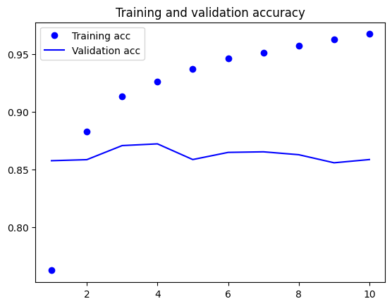

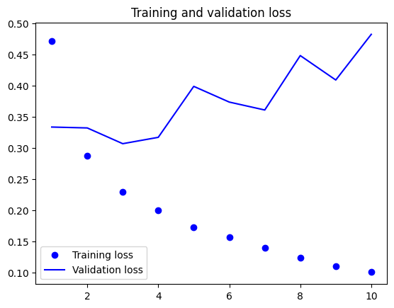

```
Training Accuracy = 0.9673333168029785
Validation Accuracy = 0.8586000204086304
```

```python
maxlen = 150 # Cut off reviews after 150 words
training_samples = 15000 # Number of training samples
validation_samples = 10000 # Number of validation samples
max_words = 10000 # Consider only the top 10000 words

x_train, y_train, x_val, y_val, word_index = preprocess_text_data(texts, labels, max_words, maxlen, training_samples, validation_samples)

model = Sequential()
model.add(Embedding(max_words, 32))
model.add(LSTM(32))
model.add(Dense(1, activation='sigmoid'))
model.compile(optimizer='rmsprop', loss='binary_crossentropy', metrics=['acc'])
history = model.fit(x_train, y_train, epochs=10, batch_size=32, validation_data=(x_val, y_val))

model.save_weights('simple_LSTM_model_15000.h5')


acc = history.history['acc']
val_acc = history.history['val_acc']
loss = history.history['loss']
val_loss = history.history['val_loss']
epochs = range(1, len(acc) + 1)
plt.plot(epochs, acc, 'bo', label='Training acc')
plt.plot(epochs, val_acc, 'b', label='Validation acc')
plt.title('Training and validation accuracy')
plt.legend()
plt.figure()
plt.plot(epochs, loss, 'bo', label='Training loss')
plt.plot(epochs, val_loss, 'b', label='Validation loss')
plt.title('Training and validation loss')
plt.legend()
plt.show()

# Access the training and validation accuracy from the history by taking the last epoch's accuracy
training_accuracy = history.history['acc']
print(f"Training Accuracy = {training_accuracy[-1]}")

validation_accuracy = history.history['val_acc']
print(f"Validation Accuracy = {validation_accuracy[-1]}")
```

# It is a decent increase from 81.98% to 85.86%. The overfitting decreased for sure compared to earlier models, but is still there. Lets use dropout to see if that reduces overfitting

# Adding dropout(0.5)

```
Found 88582 unique tokens.
Shape of data tensor: (25000, 150)
Shape of label tensor: (25000,)
```

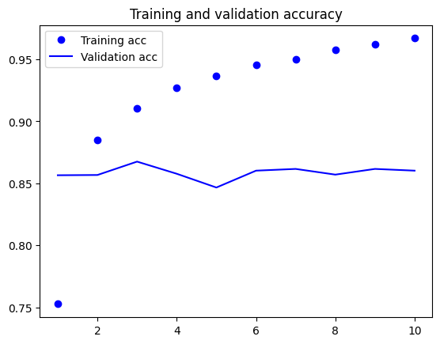

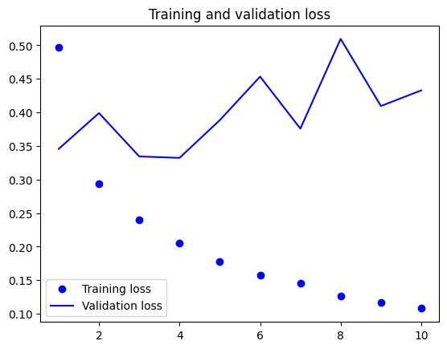

```
Training Accuracy = 0.9669333100318909
Validation Accuracy = 0.8601999878883362
```

```python
maxlen = 150 # Cut off reviews after 150 words
training_samples = 15000 # Number of training samples
validation_samples = 10000 # Number of validation samples
max_words = 10000 # Consider only the top 10000 words

x_train, y_train, x_val, y_val, word_index = preprocess_text_data(texts, labels, max_words, maxlen, training_samples, validation_samples)

model = Sequential()
model.add(Embedding(max_words, 32))
model.add(LSTM(32))
model.add(Dropout(0.5))  # Add Dropout to reduce overfitting
model.add(Dense(1, activation='sigmoid'))
model.compile(optimizer='rmsprop', loss='binary_crossentropy', metrics=['acc'])
history = model.fit(x_train, y_train, epochs=10, batch_size=32, validation_data=(x_val, y_val))
model.save_weights('simple_LSTM_model_15000_500_w_dropout.h5')

acc = history.history['acc']
val_acc = history.history['val_acc']
loss = history.history['loss']
val_loss = history.history['val_loss']
epochs = range(1, len(acc) + 1)
plt.plot(epochs, acc, 'bo', label='Training acc')
plt.plot(epochs, val_acc, 'b', label='Validation acc')
plt.title('Training and validation accuracy')
plt.legend()
plt.figure()
plt.plot(epochs, loss, 'bo', label='Training loss')
plt.plot(epochs, val_loss, 'b', label='Validation loss')
plt.title('Training and validation loss')
plt.legend()
plt.show()

# Access the training and validation accuracy from the history by taking the last epoch's accuracy
training_accuracy = history.history['acc']
print(f"Training Accuracy = {training_accuracy[-1]}")

validation_accuracy = history.history['val_acc']
print(f"Validation Accuracy = {validation_accuracy[-1]}")
```

# There is a slight increase from 85.86% to 86.02% by adding dropout(0.5)

```
Found 88582 unique tokens.
Shape of data tensor: (25000, 500)
Shape of label tensor: (25000,)
```

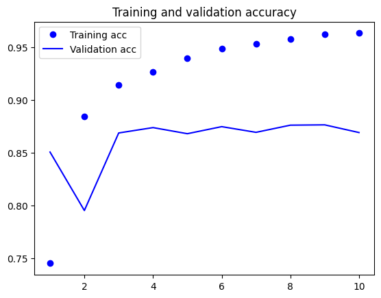

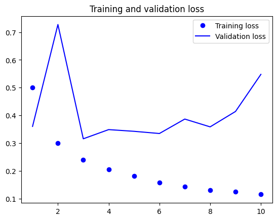

```
Training Accuracy = 0.9630666375160217
Validation Accuracy = 0.8689000010490417
```

```python
maxlen = 500 # Cut off reviews after 150 words
training_samples = 15000 # Number of training samples
validation_samples = 10000 # Number of validation samples
max_words = 10000 # Consider only the top 10000 words

x_train, y_train, x_val, y_val, word_index = preprocess_text_data(texts, labels, max_words, maxlen, training_samples, validation_samples)

model = Sequential()
model.add(Embedding(max_words, 32))
model.add(LSTM(32))
model.add(Dropout(0.5))  # Add Dropout to reduce overfitting
model.add(Dense(1, activation='sigmoid'))
model.compile(optimizer='rmsprop', loss='binary_crossentropy', metrics=['acc'])
history = model.fit(x_train, y_train, epochs=10, batch_size=32, validation_data=(x_val, y_val))
model.save_weights('simple_LSTM_model_15000_cutoff_increase_w_dropout.h5')

acc = history.history['acc']
val_acc = history.history['val_acc']
loss = history.history['loss']
val_loss = history.history['val_loss']
epochs = range(1, len(acc) + 1)
plt.plot(epochs, acc, 'bo', label='Training acc')
plt.plot(epochs, val_acc, 'b', label='Validation acc')
plt.title('Training and validation accuracy')
plt.legend()
plt.figure()
plt.plot(epochs, loss, 'bo', label='Training loss')
plt.plot(epochs, val_loss, 'b', label='Validation loss')
plt.title('Training and validation loss')
plt.legend()
plt.show()

# Access the training and validation accuracy from the history by taking the last epoch's accuracy
training_accuracy = history.history['acc']
print(f"Training Accuracy = {training_accuracy[-1]}")

validation_accuracy = history.history['val_acc']
print(f"Validation Accuracy = {validation_accuracy[-1]}")
```

# There is a slight increase from 86.02% to 86.89% by adding dropout(0.5) and using cutoff as 500

# The best model from the above is the LSTM model with dropout and word cutoff is around 500

# Preprocessing the test data before we evaluate the best model on test data

```python
import os
imdb_dir = '/kaggle/input/imdb-reviews/aclImdb'
test_dir = os.path.join(imdb_dir, 'test')
labels_test = []
texts_test = []
for label_type in ['neg', 'pos']:
    dir_name = os.path.join(test_dir, label_type)
    for fname in os.listdir(dir_name):
        if fname[-4:] == '.txt':
            f = open(os.path.join(dir_name, fname))
            texts_test.append(f.read())
            f.close()
            if label_type == 'neg':
                labels_test.append(0)
            else:
                labels_test.append(1)
```

```python
def preprocess_text_data_test(texts, labels, max_words, maxlen, test_samples):
    # Tokenize the texts
    tokenizer = Tokenizer(num_words=max_words)
    tokenizer.fit_on_texts(texts)
    sequences = tokenizer.texts_to_sequences(texts)
    word_index = tokenizer.word_index
    print('Found %s unique tokens.' % len(word_index))

    # Pad sequences
    data = pad_sequences(sequences, maxlen=maxlen)
    labels = np.asarray(labels)
    print('Shape of data tensor:', data.shape)
    print('Shape of label tensor:', labels.shape)

    # Shuffle data and labels
    indices = np.arange(data.shape[0])
    np.random.shuffle(indices)
    data = data[indices]
    labels = labels[indices]

    # Split into training and validation sets
    x_test = data[:test_samples]
    y_test = labels[:test_samples]
    return x_test, y_test, word_index

maxlen = 500 # Cut off reviews after 150 words
test_samples = 25000 # Number of training samples
max_words = 10000 # Consider only the top 10000 words

x_test, y_test, word_index = preprocess_text_data_test(texts_test, labels_test, max_words, maxlen, test_samples)
```

```
Found 87393 unique tokens.
Shape of data tensor: (25000, 500)
Shape of label tensor: (25000,)
```

```python
model.evaluate(x_test, y_test)
```

```
[2.2544612884521484, 0.5057200193405151]
```

# On test data, the best model is doing just better than a random coin flip. It is possible that the data distribution is different in train and test data and that is why the discrepancy